# Homework 6

# Submission Instructions

- Submit responses in a .ipynb file.
- For calculation questions:
  - Include R code used.
  - Ensure all code has been executed to display output.
  - Round *answers* to 3-5 decimal places if necessary.
  - Avoid displaying unnecessary R outputs.
  - Support conclusions with plots when checking assumptions.
  - Assume $\alpha = 0.05$ unless stated otherwise.
  - Two-sided hypothesis tests require two-sided confidence intervals.
  - One-sided hypothesis tests require one-sided confidence intervals.

# Question 1

Recall the data **sexSells.csv** from the previous homework. Calculate the correlation between the recall of ads with a sexual image and ads without the sexual image. Consider the direction of the correlation, what does this communicate about this data?

- Use of `cor()` and `cor.test()` is not permitted.

```r
library(tidyverse)

# Load data
ad_data <- read_csv("../Data/sexSells.csv") |>
  arrange(Image, Subject) # Put the data in order
```

```r
# Storing sexy and non-sexy observations as separate objects
sexy <- filter(ad_data, Image == "Sexy")$AdRecall
not_sexy <- filter(ad_data, Image == "NotSexy")$AdRecall

N <- length(sexy)

# Calculating Z-Scores
sexy_z <- (sexy - mean(sexy)) / sd(sexy)
not_sexy_z <- (not_sexy - mean(not_sexy)) / sd(not_sexy)

# Correlation formula
R <- sum(sexy_z * not_sexy_z) / (N - 1)
round(R, 5)
```

```
## [1] 0.52488
```

#### There is a positive correlation indicating that people who are more likely to recall the sexy ads are also more likely to recall the non-sexy ads.

# Question 2

Plot a scatterplot looking at the relationship between the recall of the two types of ads. Place nonsexual ads on the x-axis and sexual ads on the y-axis. You will probably notice that there is something odd about how the plot looks, what do think is causing the oddness?

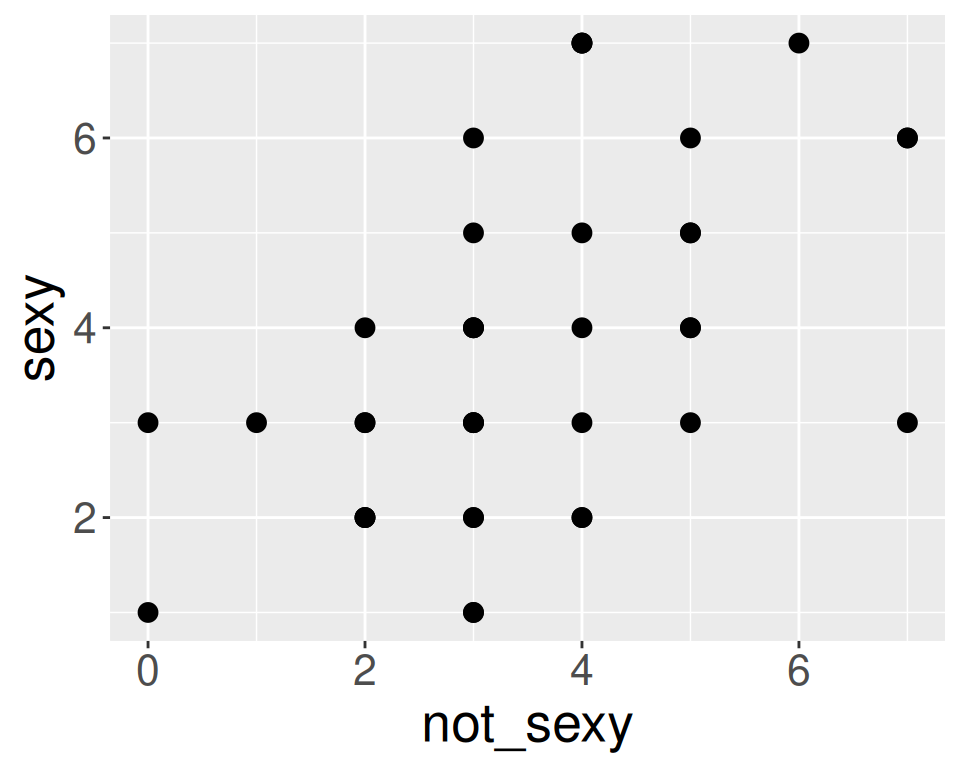

```r
ggplot(mapping = aes(x = not_sexy, y = sexy)) +
  geom_point(size = 3) +
  theme(text = element_text(size = 20))
```

There are 39 x-y pairs, but only 24 points plotted. This is because there is “overplotting” on the graph (i.e., some x-y pairs are identical and thus the points are overlapping each other).

## **FYI:**

Since the data has some overplotting in it, a good idea is to use `geom_jitter()` instead of `geom_point()`. This will add a bit of random variation to the location of each point. I never showed you this in class, but now you know.

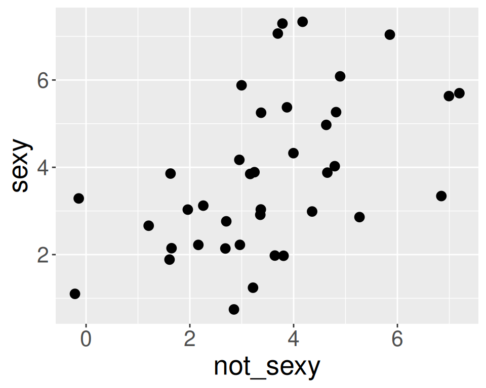

```r
# Using jitter
ggplot(mapping = aes(x = not_sexy, y = sexy)) +
  geom_jitter(size = 3) +
  theme(text = element_text(size = 20))
```

# Question 3

Construct a linear model that predicts the number of sexual ads recalled given the number of non-sexual ads recalled.

- Use of `lm()` is not permitted.
- Report the formula you produced. E.g., $\hat{y} = \text{(intercept value)} + \text{(slope value)} \cdot x$
- Plot it on your scatterplot.

```r
# Slope
b1 <- R * (sd(sexy) / sd(not_sexy))

# Intercept
b0 <- mean(sexy) - b1 * mean(not_sexy)
```

**Formula:**

$\hat{y} = 1.799 + 0.557 \cdot x$

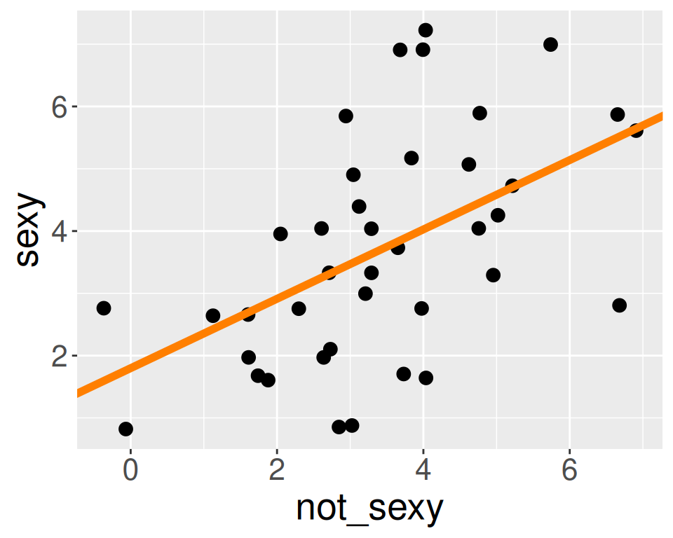

```r
# Plot
ggplot(mapping = aes(x = not_sexy, y = sexy)) +
  geom_jitter(size = 3) +
  geom_abline(
    intercept = b0,
    slope = b1,
    colour = "darkorange1",
    linewidth = 2
  ) +
  theme(text = element_text(size = 20))
```

# Question 4

You own an ice cream business and you would like to create a linear model that could predict the daily revenue in dollars based on the outside air temperature (degrees celsius). Use the data **IceCreamData.csv** to create this model.

- Use of `lm()`, `cor`, and `cor.test()` is not permitted.
- Report the model’s formula.

```r
ice_cream <- read_csv("../Data/IceCreamData.csv")

# Sample size
N <- nrow(ice_cream)
```

```r
# Correlation
temp_z <- (ice_cream$Temperature - mean(ice_cream$Temperature)) /
  sd(ice_cream$Temperature)
rev_z <- (ice_cream$Revenue - mean(ice_cream$Revenue)) /
  sd(ice_cream$Revenue)

R <- sum(temp_z * rev_z) / (N - 1)
```

```r
# Slope
b1 <- R * (sd(ice_cream$Revenue) / sd(ice_cream$Temperature))

# Intercept
b0 <- mean(ice_cream$Revenue) - b1 * mean(ice_cream$Temperature)
```

**Formula:**

$\hat{y} = 44.831 + 21.444 \cdot x$

# Question 5

Plot the model you created in the previous question. Make the plot pretty with fun colours and appropriate axis labels.

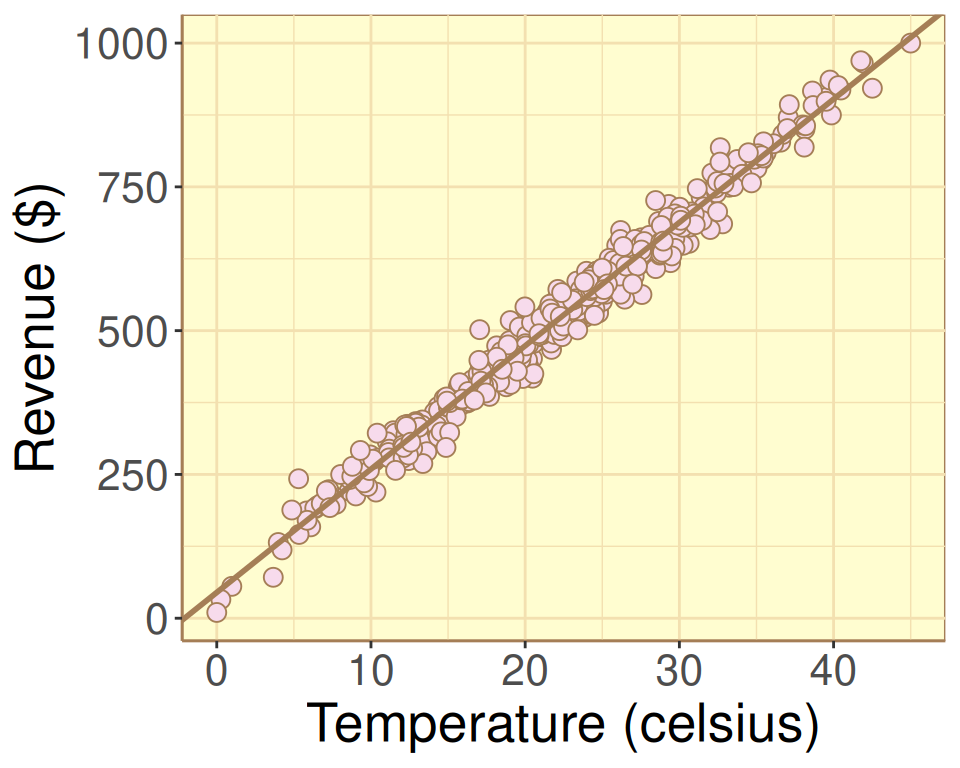

```r
ggplot(ice_cream, aes(x = Temperature, y = Revenue)) +
  geom_point(
    shape = 21, size = 3,
    fill = "#F7DBEC", colour = "#A57E56", stroke = .5
  ) +

  geom_abline(
    intercept = b0, slope = b1,
    colour = "#A57E56",
    linewidth = 1
  ) +

  xlab("Temperature (celsius)") +
  ylab("Revenue ($)") +

  theme(
    panel.background = element_rect(
      fill = "#FFFDD0",
      colour = "#A57E56",
      linewidth = 0.5
    ),
    axis.line = element_line(colour = "#A57E56", linewidth = 0.5),
    panel.grid.major = element_line(color = "#F3E0B0"),
    panel.grid.minor = element_line(color = "#F3E0B0")
  ) +
  theme(text = element_text(size = 20))
```

# Question 6

Create a plot of the residuals for the ice cream model you created. Does the plot indicate any patterns or heteroscedasticity?

- Use of `lm()` is not permitted.

```r
# Model predictions (y_hat; i.e., fitted values)
ice_cream$y_hat <- b0 + b1 * ice_cream$Temperature

# Residuals
ice_cream$resid <- ice_cream$Revenue - ice_cream$y_hat
```

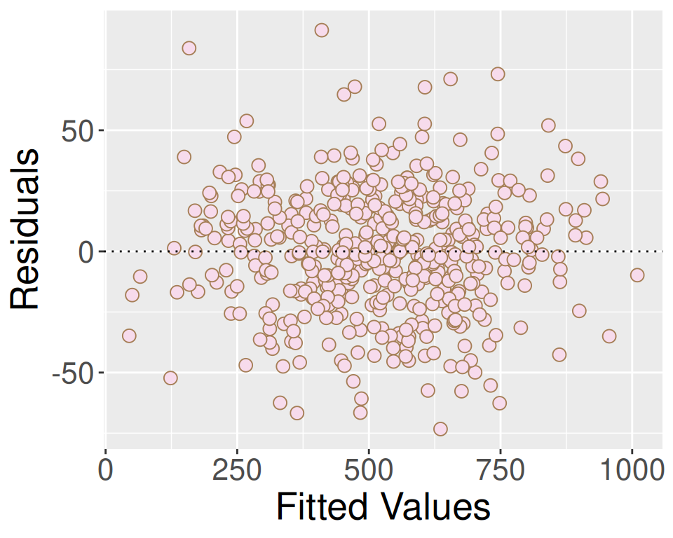

```r
ggplot(ice_cream, aes(x = y_hat, y = resid)) +
  geom_point(
    shape = 21, size = 3,
    fill = "#F7DBEC",
    colour = "#A57E56",
    stroke = .5
  ) +
  geom_hline(yintercept = 0, linetype = 3) +
  xlab("Fitted Values") + ylab("Residuals") +
  theme(text = element_text(size = 20))
```

There are no obvious patterns or heteroscedasticity.

# Question 7

Assess the normality of the residuals from the previous question - is it reasonable to assume they are normally distributed?

- Use of `lm()` is not permitted.

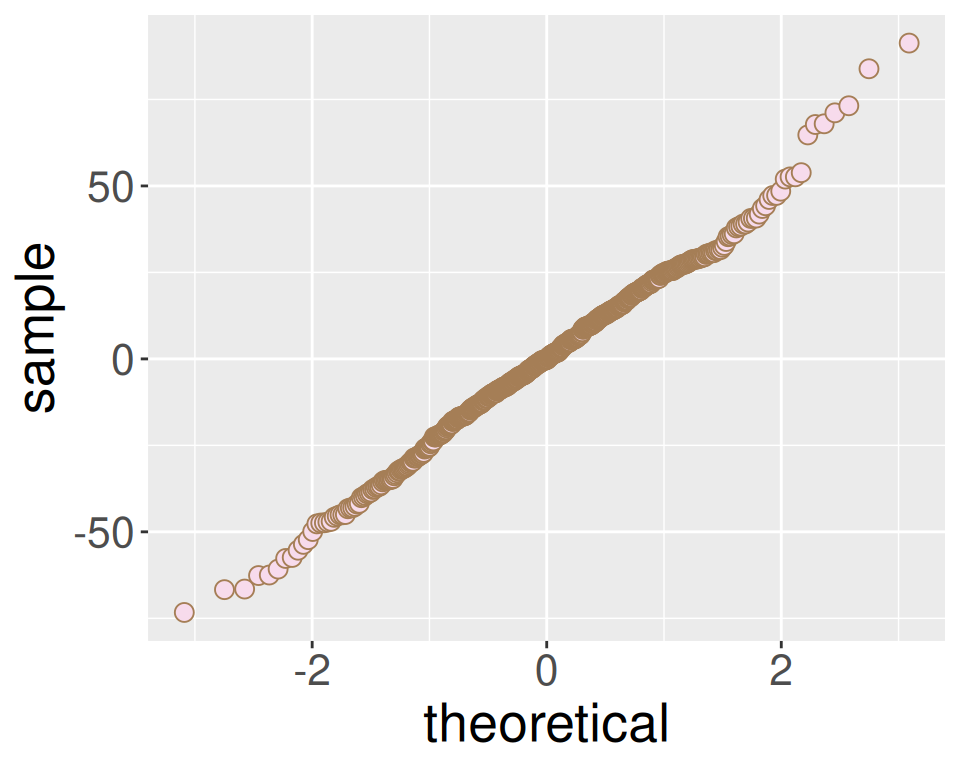

```r
ggplot(ice_cream, aes(sample = resid)) +
  stat_qq(
    shape = 21,
    size = 3,
    fill = "#F7DBEC",
    colour = "#A57E56",
    stroke = .5
  ) +
  theme(text = element_text(size = 20))
```

It seems reasonable to assume the residuals are normally distributed.

# Question 8

How much variation in the revenue does the ice cream model account for?

```r
R^2
```

```
## [1] 0.9797072
```

It accounts for 97.971 % of the variance.

# Question 9

Report the standard error of the slope and intercept for the previous question’s model.

- Use of `lm()` is not permitted.

```r
#Squared Standard Error of the Residuals
N <- nrow(ice_cream)
res_var <- sum((ice_cream$Revenue - ice_cream$y_hat)^2)/ (N - 2)

#Sum of Squares for X
ss_x <- sum((ice_cream$Temperature - mean(ice_cream$Temperature))^2)

#Slope Standard Error
s_b1 <- sqrt(res_var / ss_x)

#Intercept Standard Error
s_b0 <- sqrt((res_var * sum(ice_cream$Temperature^2)) / (N * ss_x))

# Print
s_b1
s_b0
```

```
## [1] 0.138295
## [1] 3.271757
```

The slope has a standard error of 0.1383.

The intercept has a standard error of 3.2718.

# Question 10

Conduct a t-test on the slope from the ice cream model. Use of `lm()` and `confint()` is not permitted. Report the following:

- null hypothesis
- test statistic
- degrees of freedom
- p-value
- Confidence interval

```r
# Test Statistic
beta1 <- 0
t_stat <- (b1 - beta1) / s_b1

# Degrees of Freedom
P <- 1
df <- N - P - 1

# P-value
p <- pt(t_stat, df = df, lower.tail = FALSE) * 2

# T_crit
alpha <- 0.05
t_crit <- abs(qt(alpha / 2, df = df))

# Confidence Interval
lower <- b1 - t_crit * s_b1
upper <- b1 + t_crit * s_b1
```

```
## [1] "H0: B1 = 0"
```

```
## [1] "T = 155.0572"
```

```
## [1] "df = 498"
```

```
## [1] "p = 0"
```

```
## [1] "95% CI: [21.1719, 21.7153]"
```

# Question 11

In about 5 billion years, the Sun’s hydrogen core will be depleted and it will expand outwards engulfing Earth. The Sun (now a “red giant”) will have a surface temperature of about 4726.85 degrees celsius when it consumes Earth. When this happens, what is your predicted ice cream revenue?

```r
b0 + b1 * 4726.85
```

```
## [1] 101405.6
```

You are predicted to earn about $101405.6.